# Lab week 1 - penalized linear models

Data Science 2: Machine Learning Concepts - CEU 2019

Jeno Pal

2019-02-04

```r
library(data.table)
library(ggplot2)
library(GGally) # ggplot extensions, install if it is missing
library(caret)
library(magrittr)
library(skimr)
library(janitor)  # for data cleaning purposes
library(glmnet)   # the main package for penalized linear models
theme_set(theme_bw())   # globally set ggplot theme
```

Disclaimer: this lab borrows lots of ideas and examples from [this](https://afit-r.github.io/regularized_regression) great tutorial.

## Data: Ames Housing dataset

We are going to predict house sales prices in Ames, Iowa. See [here](https://cran.r-project.org/web/packages/AmesHousing/index.html).

```r
library(AmesHousing)
housing_data <- AmesHousing::make_ames() %>% as.data.table()
housing_data <- clean_names(housing_data)
housing_data[, log_sale_price := log(sale_price)]
skim(housing_data)
```

```
Skim summary statistics
 n obs: 2930
 n variables: 82

── Variable type:factor ──────────────────────────────────────────────────────────────────────
        variable missing complete    n n_unique                              top_counts
           alley       0     2930 2930        3     No_: 2732, Gra: 120, Pav: 78, NA: 0
       bldg_type       0     2930 2930        5 One: 2425, Twn: 233, Dup: 109, Twn: 101
       bsmt_cond       0     2930 2930        6  Typ: 2616, Goo: 122, Fai: 104, No_: 80
   bsmt_exposure       0     2930 2930        5     No: 1906, Av: 418, Gd: 284, Mn: 239
 bsmt_fin_type_1       0     2930 2930        7  GLQ: 859, Unf: 851, ALQ: 429, Rec: 288
 bsmt_fin_type_2       0     2930 2930        7   Unf: 2499, Rec: 106, LwQ: 89, No_: 81
       bsmt_qual       0     2930 2930        6 Typ: 1283, Goo: 1219, Exc: 258, Fai: 88
     central_air       0     2930 2930        2                  Y: 2734, N: 196, NA: 0
     condition_1       0     2930 2930        9   Nor: 2522, Fee: 164, Art: 92, RRA: 50
     condition_2       0     2930 2930        8      Nor: 2900, Fee: 13, Art: 5, Pos: 4
      electrical       0     2930 2930        6    SBr: 2682, Fus: 188, Fus: 50, Fus: 8
      exter_cond       0     2930 2930        5   Typ: 2549, Goo: 299, Fai: 67, Exc: 12
      exter_qual       0     2930 2930        4  Typ: 1799, Goo: 989, Exc: 107, Fai: 35
    exterior_1st       0     2930 2930       16 Vin: 1026, Met: 450, HdB: 442, Wd : 420
    exterior_2nd       0     2930 2930       17 Vin: 1015, Met: 447, HdB: 406, Wd : 397
           fence       0     2930 2930        5 No_: 2358, Min: 330, Goo: 118, Goo: 112
    fireplace_qu       0     2930 2930        6  No_: 1422, Goo: 744, Typ: 600, Fai: 75
      foundation       0     2930 2930        6 PCo: 1310, CBl: 1244, Brk: 311, Sla: 49
      functional       0     2930 2930        8    Typ: 2728, Min: 70, Min: 65, Mod: 35
     garage_cond       0     2930 2930        6   Typ: 2665, No_: 159, Fai: 74, Goo: 15
   garage_finish       0     2930 2930        4 Unf: 1231, RFn: 812, Fin: 728, No_: 159
     garage_qual       0     2930 2930        6  Typ: 2615, No_: 159, Fai: 124, Goo: 24
     garage_type       0     2930 2930        7 Att: 1731, Det: 782, Bui: 186, No_: 157
         heating       0     2930 2930        6      Gas: 2885, Gas: 27, Gra: 9, Wal: 6
      heating_qc       0     2930 2930        5  Exc: 1495, Typ: 864, Goo: 476, Fai: 92
     house_style       0     2930 2930        8 One: 1481, Two: 873, One: 314, SLv: 128
    kitchen_qual       0     2930 2930        5 Typ: 1494, Goo: 1160, Exc: 205, Fai: 70
    land_contour       0     2930 2930        4  Lvl: 2633, HLS: 120, Bnk: 117, Low: 60
      land_slope       0     2930 2930        3     Gtl: 2789, Mod: 125, Sev: 16, NA: 0
      lot_config       0     2930 2930        5  Ins: 2140, Cor: 511, Cul: 180, FR2: 85
       lot_shape       0     2930 2930        4   Reg: 1859, Sli: 979, Mod: 76, Irr: 16
    mas_vnr_type       0     2930 2930        5  Non: 1775, Brk: 880, Sto: 249, Brk: 25
    misc_feature       0     2930 2930        6      Non: 2824, She: 95, Gar: 5, Oth: 4
    ms_sub_class       0     2930 2930       16 One: 1079, Two: 575, One: 287, One: 192
```

[output cut: 124 more lines]

```
  total_bsmt_sf       0     2930 2930 1051.26  440.97    0    793    990    1301.5  6110
     hist
 ▁▃▂▇▂▁▃▇
 ▇▁▁▁▁▁▁▁
 ▇▁▆▁▁▁▁▁
 ▇▁▁▁▁▁▁▁
 ▇▆▅▂▁▁▁▁
 ▁▅▇▃▂▁▁▁
 ▁▃▁▇▂▁▁▁
 ▂▁▁▇▇▇▆▇
 ▁▁▁▁▇▇▂▁
 ▆▃▆▇▇▇▂▁
 ▃▇▃▁▁▁▁▁
 ▇▁▁▁▁▁▁▁
 ▃▇▂▁▁▁▁▁
```

Look at the outcome variable, the price of houses.

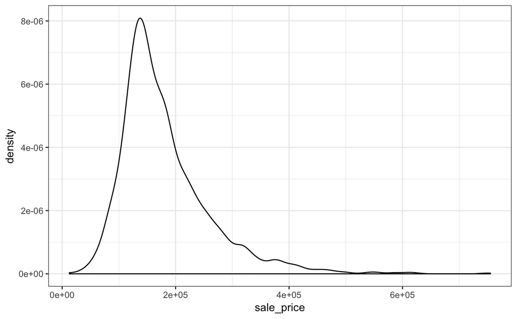

```r
ggplot(data = housing_data, aes(x = sale_price)) + geom_density()
```

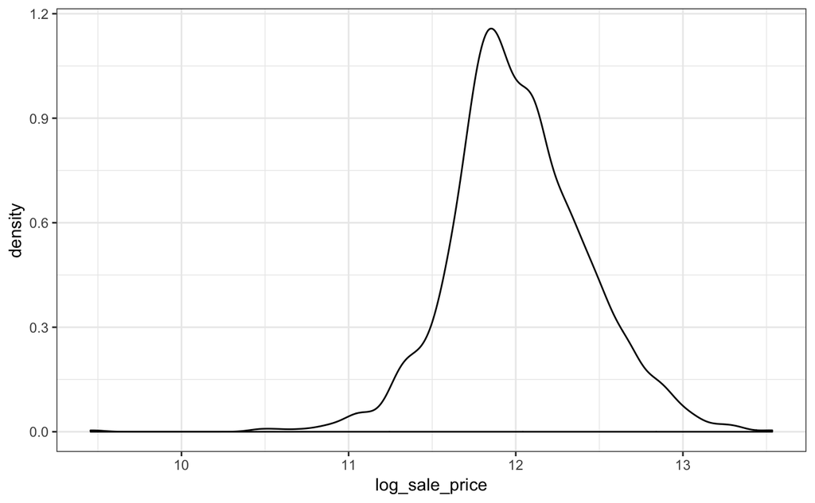

```r
ggplot(data = housing_data, aes(x = log_sale_price)) + geom_density()
```

Let’s see correlations of features and the outcome variable. Based on this, simple benchmark models can quickly be put together.

[output not shown]

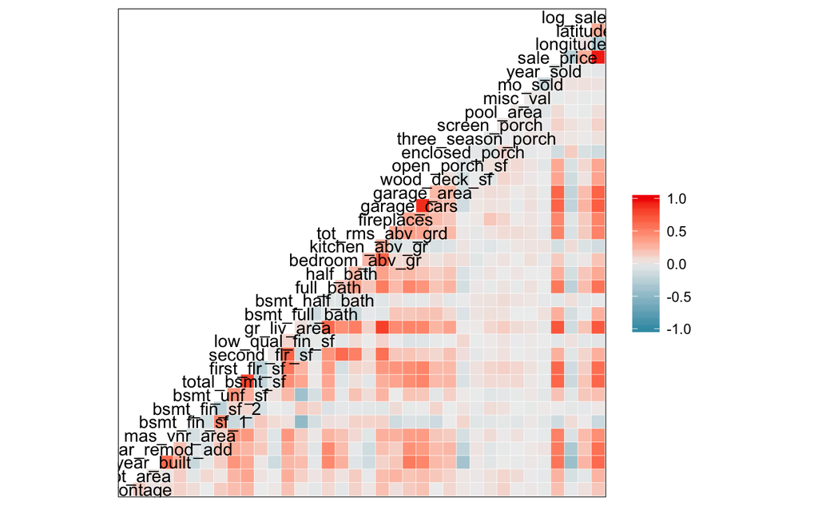

```r
ggcorr(housing_data)
```

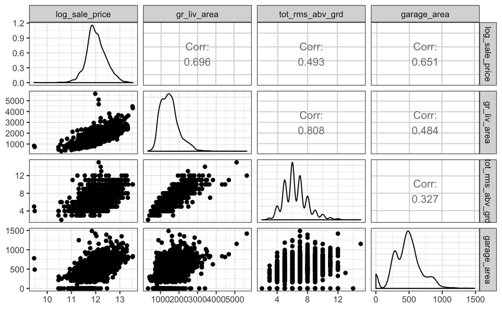

```r
ggpairs(housing_data, columns = c("log_sale_price", "gr_liv_area", "tot_rms_abv_grd", "garage_area"))
```

### A baseline model

```r
lm(log_sale_price ~ gr_liv_area + tot_rms_abv_grd, data = housing_data)
```

```
Call:
lm(formula = log_sale_price ~ gr_liv_area + tot_rms_abv_grd,
    data = housing_data)

Coefficients:
    (Intercept)      gr_liv_area  tot_rms_abv_grd
     11.3181311        0.0006914       -0.0518376
```

Weird pattern: sales price decreases with the number of rooms? This is spurious and is caused by the high positive correlation between the feature variables. Univariate regressions have the intuitive signs:

```r
lm(log_sale_price ~ gr_liv_area, data = housing_data)
```

```
Call:
lm(formula = log_sale_price ~ gr_liv_area, data = housing_data)

Coefficients:
(Intercept)  gr_liv_area
  1.118e+01    5.611e-04
```

```r
lm(log_sale_price ~ tot_rms_abv_grd, data = housing_data)
```

```
Call:
lm(formula = log_sale_price ~ tot_rms_abv_grd, data = housing_data)

Coefficients:
    (Intercept)  tot_rms_abv_grd
        11.1986           0.1276
```

Penalized methods offer a solution to these kinds of patterns.

### Set up training and test (holdout) datasets

```r
set.seed(1234)
training_ratio <- 0.5
train_indices <- createDataPartition(
  y = housing_data[["log_sale_price"]],
  times = 1,
  p = training_ratio,
  list = FALSE
)
data_train <- housing_data[train_indices, ]
data_test <- housing_data[-train_indices, ]
fit_control <- trainControl(method = "cv", number = 10)
```

## Penalize large coefficients: the Ridge regression

```r
features <- setdiff(names(housing_data), c("sale_price", "log_sale_price"))
```

First we are going to directly work with the `glmnet` package to estimate penalized models. Then we look at how this can be implemented through `caret`.

```r
# glmnet needs inputs as a matrix. model.matrix: handles factor variables
# -1: we do not need the intercept as glment will automatically include it
x_train <- model.matrix( ~ . -1, data_train[, features, with = FALSE])
dim(x_train)
```

```
[1] 1466  308
```

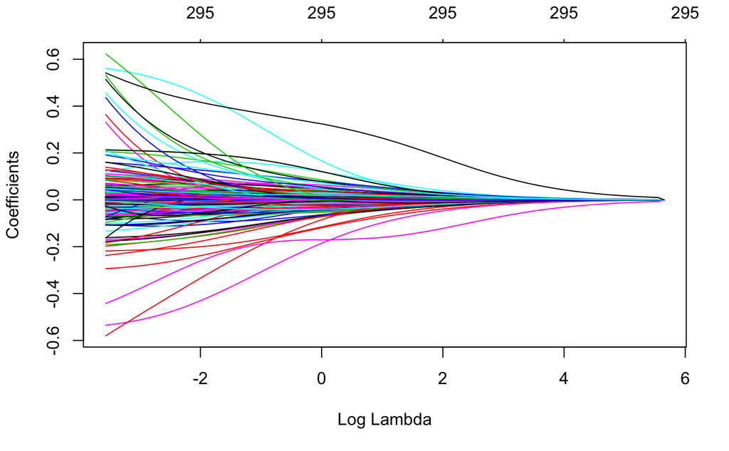

```r
# standardization of variables is automatically done by glmnet
# how much penalty do we want to apply? select with CV
lambda_grid <- 10^seq(2,-5,length=100)
set.seed(1234)
ridge_model <- glmnet(
  x = x_train, y = data_train[["log_sale_price"]],
  family = "gaussian", # for continuous response
  alpha = 0  # the ridge model
)
plot(ridge_model, xvar = "lambda")
```

We can use cross-validation to determine the optimal penalty term weight. Two lambda values marked on the plot: one with the minimal CV RMSE, the other is the simplest model (highest lambda) which contains the optimal lambda’s error within one standard deviation. That is, it gives the simplest model that is still “good enough”.

```r
set.seed(1234)
ridge_model_cv <- cv.glmnet(
  x = x_train, y = data_train[["log_sale_price"]],
  family = "gaussian",
  alpha = 0,
  nfolds = 10
)
best_lambda <- ridge_model_cv$lambda.min
message(paste0("The optimally chosen penalty parameter: ", best_lambda))
```

```
The optimally chosen penalty parameter: 0.182382522269488
```

```r
highest_good_enough_lambda <- ridge_model_cv$lambda.1se
message(paste0("The optimally chosen penalty parameter: ", highest_good_enough_lambda))
```

```
The optimally chosen penalty parameter: 1.06821822802353
```

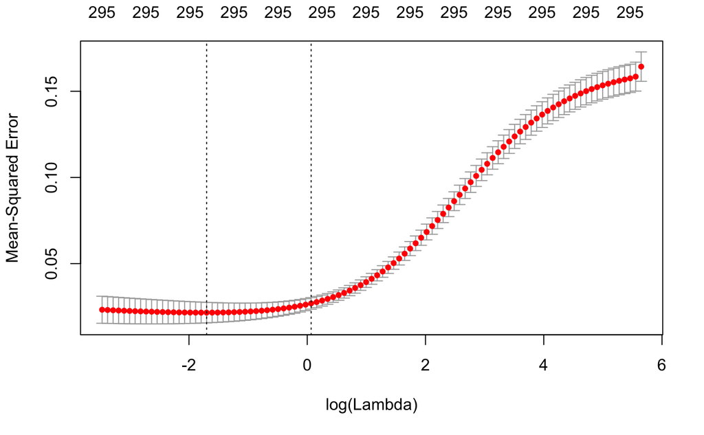

```r
plot(ridge_model_cv)
```

We can also use `caret` to estimate ridge models. This lets us compare it later to any other model estimated with caret, using, for example, cross-validation with exactly the same folds.

```r
# ridge model
ridge_tune_grid <- expand.grid(
  "alpha" = c(0),
  "lambda" = seq(0.05, 0.5, by = 0.025)
)
set.seed(857)
ridge_fit <- train(
  log_sale_price ~ . -sale_price,
  data = data_train,
  method = "glmnet",
  preProcess = c("center", "scale"),
  tuneGrid = ridge_tune_grid,
  trControl = fit_control
)
```

```r
ridge_fit
```

```
glmnet

1466 samples
  81 predictor

Pre-processing: centered (307), scaled (307)
Resampling: Cross-Validated (10 fold)
Summary of sample sizes: 1320, 1319, 1319, 1320, 1321, 1318, ...
Resampling results across tuning parameters:

  lambda  RMSE       Rsquared   MAE
  0.050   0.1586210  0.8537261  0.09202424
  0.075   0.1559363  0.8577380  0.09147644
  0.100   0.1542033  0.8604295  0.09147504
  0.125   0.1530577  0.8623161  0.09166529
  0.150   0.1523128  0.8636538  0.09193287
  0.175   0.1518547  0.8646004  0.09227020
  0.200   0.1516083  0.8652635  0.09267839
  0.225   0.1515291  0.8656976  0.09314123
  0.250   0.1515732  0.8659700  0.09360719
  0.275   0.1517163  0.8661126  0.09410232
  0.300   0.1519401  0.8661493  0.09460896
  0.325   0.1522293  0.8661013  0.09512139
  0.350   0.1525729  0.8659836  0.09563901
  0.375   0.1529564  0.8658132  0.09616220
  0.400   0.1533709  0.8656027  0.09667479
  0.425   0.1538198  0.8653497  0.09719315
  0.450   0.1542945  0.8650654  0.09772228
  0.475   0.1547944  0.8647522  0.09824967
  0.500   0.1553150  0.8644162  0.09876697

Tuning parameter 'alpha' was held constant at a value of 0
RMSE was used to select the optimal model using the smallest value.
The final values used for the model were alpha = 0 and lambda = 0.225.
```

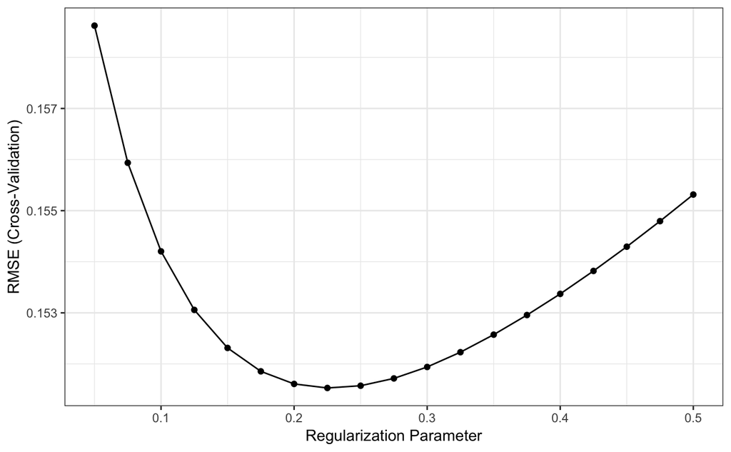

```r
ggplot(ridge_fit)
```

## Another variant: LASSO regression

While Ridge applies a constraint on the sum of squares of coefficients, LASSO does the same for the sum of the **absolute values** of coefficients.

This seemingly small difference has important sconsequences: some coefficients are set exactly to zero, others are only shrunk towards zero.

```r
set.seed(1234)
lasso_model <- glmnet(
  x = x_train, y = data_train[["log_sale_price"]],
  family = "gaussian",
  alpha = 1  # the lasso model
)

plot(lasso_model, xvar = "lambda")
```

[output not shown]

```r
tenpowers <- 10^seq(-1, -5, by = -1)
lasso_tune_grid <- expand.grid(
  "alpha" = c(1),
  "lambda" = c(tenpowers, tenpowers / 2)
)
set.seed(857)
lasso_fit <- train(
  log_sale_price ~ . -sale_price,
  data = data_train,
  method = "glmnet",
  preProcess = c("center", "scale"),
  tuneGrid = lasso_tune_grid,
  trControl = fit_control
)
```

[output not shown]

```r
lasso_fit
```

[output not shown]

[figure not shown]

### Variable selection - why is it happening?

The constraints are different: LASSO’s has corners, Ridge’s is smooth.

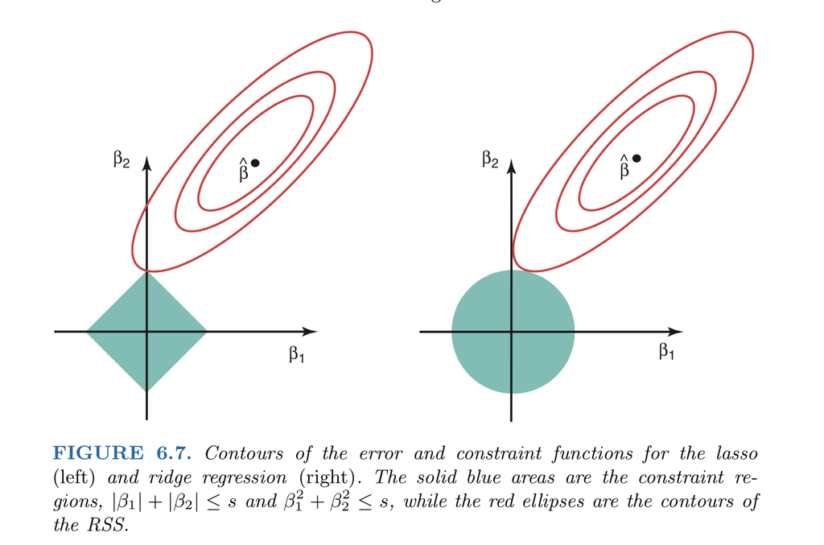

Source: Introduction to Statistical Learning

## Combine Ridge and LASSO: Elastic net

We can combine both types of penalties. LASSO is attractive since it performs principled variable selection. However, when having correlated features, typically only one of them - quite arbitrarily - is kept in the model. Ridge simultaneously shrinks coefficients of these towards zero. If we apply penalties of both the absolute values and the squares of the coefficients, both virtues are retained. This method is called Elastic net.

```r
enet_tune_grid <- expand.grid(
  "alpha" = seq(0, 1, by = 0.1),
  "lambda" = union(lasso_tune_grid[["lambda"]], ridge_tune_grid[["lambda"]])
)
```

[output not shown]

```r
enet_fit
```

[output not shown]

```r
ggplot(enet_fit) + scale_x_log10()
```

[output not shown]

## Evaluate all models

For completeness, estimate the non-regularized linear model as well.

```r
set.seed(857)
linear_fit <- train(
  log_sale_price ~ . -sale_price,
  data = data_train,
  method = "lm",
  preProcess = c("center", "scale"),
  trControl = fit_control
)
```

[output not shown]

```r
resamples(
  list("linear" = linear_fit,
       "ridge" = ridge_fit,
       "lasso" = lasso_fit,
       "elastic net" = enet_fit
  )
) %>% summary()
```

```
Call:
summary.resamples(object = .)

Models: linear, ridge, lasso, elastic net
Number of resamples: 10

MAE
                  Min.    1st Qu.     Median       Mean    3rd Qu.      Max. NA's
linear      0.07954694 0.08574556 0.09370874 0.09543165 0.10562725 0.1151239    0
ridge       0.08070960 0.08756106 0.09433989 0.09314123 0.09642730 0.1107863    0
lasso       0.07716905 0.08377913 0.08912316 0.09058530 0.09616743 0.1071293    0
elastic net 0.08070960 0.08756106 0.09433989 0.09314123 0.09642730 0.1107863    0

RMSE
                 Min.   1st Qu.    Median      Mean   3rd Qu.      Max. NA's
linear      0.1085431 0.1235400 0.1593246 0.1743029 0.2054420 0.2967257    0
ridge       0.1095676 0.1237788 0.1420113 0.1515291 0.1794968 0.2281227    0
lasso       0.0997270 0.1354289 0.1762812 0.1709034 0.1882126 0.2636285    0
elastic net 0.1095676 0.1237788 0.1420113 0.1515291 0.1794968 0.2281227    0

Rsquared
                 Min.   1st Qu.    Median      Mean   3rd Qu.      Max. NA's
linear      0.6221370 0.7945453 0.8562941 0.8335600 0.9055679 0.9286634    0
ridge       0.7161960 0.8431129 0.8842914 0.8656976 0.9167886 0.9274994    0
lasso       0.6692471 0.7986893 0.8328637 0.8370981 0.8986337 0.9398385    0
elastic net 0.7161960 0.8431129 0.8842914 0.8656976 0.9167886 0.9274994    0
```

### Evaluate the chosen model on holdout set

```r
RMSE(predict(enet_fit, newdata = data_test), data_test[["log_sale_price"]])
```

```
[1] 0.1345295
```

## Recommended readings

- [Tutorial of the Air Force Institute of Technology](https://afit-r.github.io/regularized_regression) - based on which this lab was put together
- [Elements of Statistical Learning](https://web.stanford.edu/~hastie/ElemStatLearn/) - the standard reference book of machine learning (freely available)
- [Introduction to Statistical Learning](http://www-bcf.usc.edu/~gareth/ISL/) - a more accessible treatment of the same material from the same authors (with R codes)
- [Applied Predictive Modelling](http://appliedpredictivemodeling.com/) - a thorough and practical guide to predictive modelling from the author of the `caret` package (with R code)